# Weather and Corn Yield Regressions

Avery Driscoll

3/2/2022

## Weather Data Analysis

### Load the PRISM daily maximum temperatures

```r
# daily max temperature
# dimensions: counties x days x years
prism <- readMat("data/prismiowa.mat")

# look at county #1
t_1981_c1 <- prism$tmaxdaily.iowa[1,,1]
t_1981_c1[366]
```

```
## [1] NaN
```

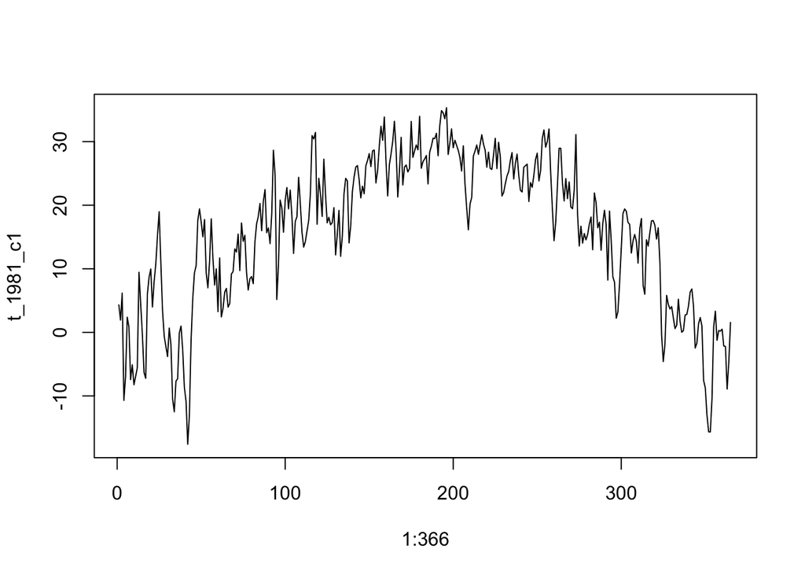

```r
plot(1:366, t_1981_c1, type = "l")
```

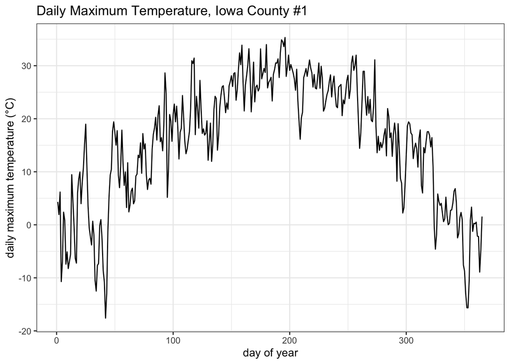

```r
ggplot() +
  geom_line(mapping = aes(x=1:366, y = t_1981_c1)) +
  theme_bw() +
  xlab("day of year") +
  ylab("daily maximum temperature (°C)") +
  ggtitle("Daily Maximum Temperature, Iowa County #1")
```

```r
# assign dimension names to tmax matrix
dimnames(prism$tmaxdaily.iowa) <- list(prism$COUNTYFP, 1:366, prism$years)

# converted 3d matrix into a data frame
tmaxdf <- as.data.frame.table(prism$tmaxdaily.iowa)

# relabel the columns
colnames(tmaxdf) <- c("countyfp","doy","year","tmax")
tmaxdf <- tibble(tmaxdf)
```

## Temperature trends

### Summer temperature trends: Winneshiek County

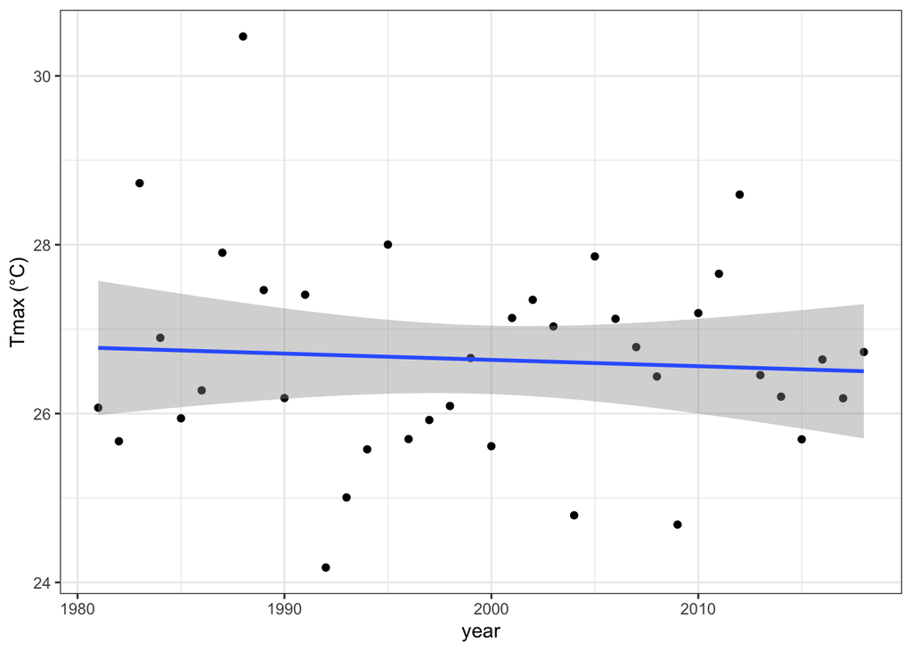

```r
tmaxdf$doy <- as.numeric(tmaxdf$doy)
tmaxdf$year <- as.numeric(as.character(tmaxdf$year))

winnesummer <- tmaxdf %>%
  filter(countyfp==191 & doy >= 152 & doy <= 243) %>%
  group_by(year) %>%
  summarize(meantmax = mean(tmax))

ggplot(winnesummer, mapping = aes(x = year, y = meantmax)) +
  geom_point() +
  theme_bw() +
  labs(x = "year", y = "Tmax (°C)") +
  geom_smooth(method = lm)
```

```r
lm_summertmax <- lm(meantmax ~ year, winnesummer)
summary(lm_summertmax)
```

```
##
## Call:
## lm(formula = meantmax ~ year, data = winnesummer)
##
## Residuals:
##     Min      1Q  Median      3Q     Max
## -2.5189 -0.7867 -0.0341  0.6859  3.7415
##
## Coefficients:
##             Estimate Std. Error t value Pr(>|t|)
## (Intercept) 41.57670   36.44848   1.141    0.262
## year        -0.00747    0.01823  -0.410    0.684
##
## Residual standard error: 1.232 on 36 degrees of freedom
## Multiple R-squared:  0.004644,   Adjusted R-squared:  -0.02301
## F-statistic: 0.168 on 1 and 36 DF,  p-value: 0.6844
```

### Winter Temperatures - Winneshiek County

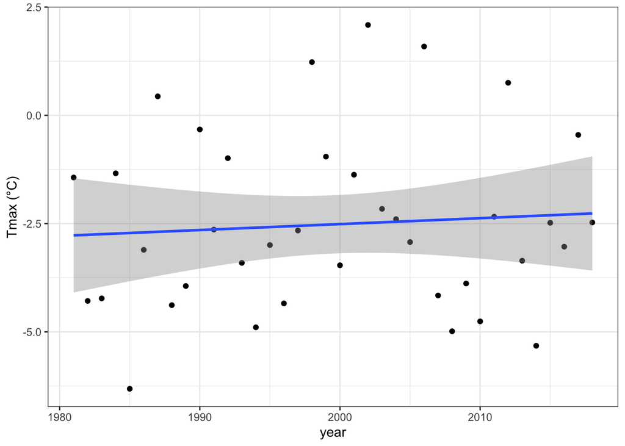

```r
winnewinter <- tmaxdf %>%
  filter(countyfp==191 & (doy <= 59 | doy >= 335) & !is.na(tmax)) %>%
  group_by(year) %>%
  summarize(meantmax = mean(tmax))

ggplot(winnewinter, mapping = aes(x = year, y = meantmax)) +
  geom_point() +
  theme_bw() +
  labs(x = "year", y = "Tmax (°C)") +
  geom_smooth(method = lm)
```

```r
lm_wintertmax <- lm(meantmax ~ year, winnewinter)
summary(lm_wintertmax)
```

```
##
## Call:
## lm(formula = meantmax ~ year, data = winnewinter)
##
## Residuals:
##     Min      1Q  Median      3Q     Max
## -3.5978 -1.4917 -0.3053  1.3778  4.5709
##
## Coefficients:
##              Estimate Std. Error t value Pr(>|t|)
## (Intercept) -29.87825   60.48100  -0.494    0.624
## year          0.01368    0.03025   0.452    0.654
##
## Residual standard error: 2.045 on 36 degrees of freedom
## Multiple R-squared:  0.005652,   Adjusted R-squared:  -0.02197
## F-statistic: 0.2046 on 1 and 36 DF,  p-value: 0.6537
```

### Multiple regression – Quadratic time trend

```r
winnewinter$yearsq <- winnewinter$year^2

lm_wintertmaxquad <- lm(meantmax ~ year + yearsq, winnewinter)
summary(lm_wintertmaxquad)
```

```
##
## Call:
## lm(formula = meantmax ~ year + yearsq, data = winnewinter)
##
## Residuals:
##     Min      1Q  Median      3Q     Max
## -3.3539 -1.2985 -0.2813  1.4055  4.2620
##
## Coefficients:
##               Estimate Std. Error t value Pr(>|t|)
## (Intercept) -1.086e+04  1.238e+04  -0.877    0.386
## year         1.085e+01  1.239e+01   0.876    0.387
## yearsq      -2.710e-03  3.097e-03  -0.875    0.388
##
## Residual standard error: 2.051 on 35 degrees of freedom
## Multiple R-squared:  0.02694,    Adjusted R-squared:  -0.02867
## F-statistic: 0.4845 on 2 and 35 DF,  p-value: 0.6201
```

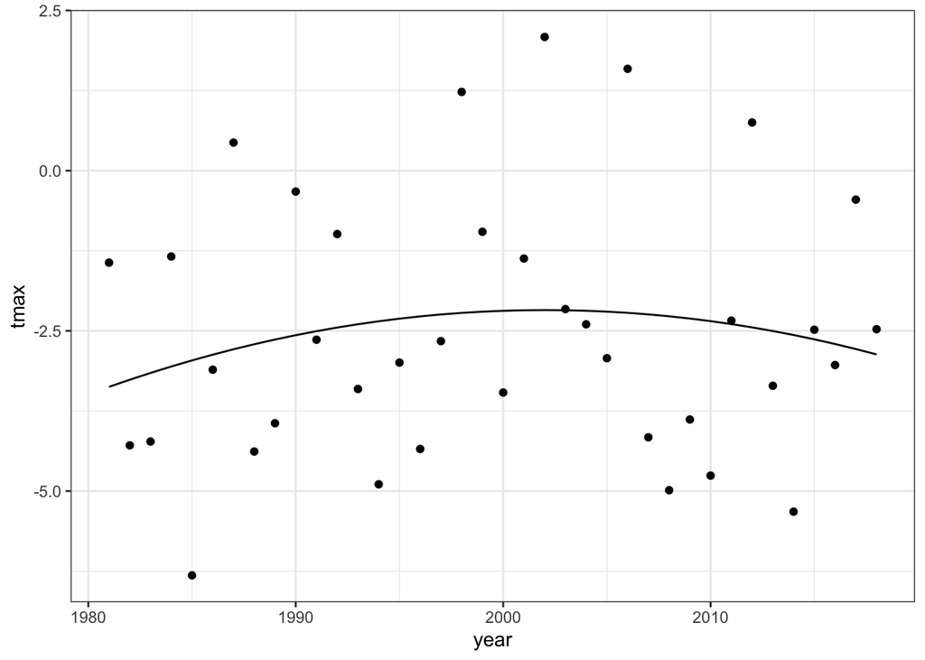

```r
winnewinter$fitted <- lm_wintertmaxquad$fitted.values

ggplot(winnewinter) +
  geom_point(mapping = aes(x = year, y = meantmax)) +
  geom_line(mapping = aes(x = year, y = fitted)) +
  theme_bw() +
  labs(x = "year", y = "tmax")
```

### Download NASS corn yield data

```r
# set our API key with NASS
nassqs_auth(key = "88135768-C75A-3AB0-9F93-00FA96F7B2CB")

# parameters to query on
params <- list(commodity_desc = "CORN", util_practice_desc = "GRAIN", prodn_practice_desc = "ALL PRODUCTION PRACTICES", year__GE = 1981, state_alpha = "IA")

# download
cornyieldsall <- nassqs_yields(params)

cornyieldsall$county_ansi <- as.numeric(cornyieldsall$county_ansi)
cornyieldsall$yield <- as.numeric(cornyieldsall$Value)

# clean and filter this dataset
cornyields <- select(cornyieldsall, county_ansi, county_name, yield, year) %>%
  filter(!is.na(county_ansi) & !is.na(yield))
cornyields <- tibble(cornyields)
```

## Assignment

### Question 1a: Extract Winneshiek County corn yields, fit a linear time trend, make a plot. Is there a significant time trend?

Yes, there is a significant linear relationship between yields and year.

```r
#Subset winneshiek county
winne_corn <- cornyields %>%
  filter(county_ansi==191)

#Fit model of yields by year and print output
mod1 <- lm(yield~year, winne_corn)
summary(mod1)
```

```
##
## Call:
## lm(formula = yield ~ year, data = winne_corn)
##
## Residuals:
##     Min      1Q  Median      3Q     Max
## -51.163  -1.841   2.363   9.437  24.376
##
## Coefficients:
##              Estimate Std. Error t value Pr(>|t|)
## (Intercept) -4763.290    448.286  -10.63 4.46e-13 ***
## year            2.457      0.224   10.96 1.77e-13 ***
## ---
## Signif. codes:  0 '***' 0.001 '**' 0.01 '*' 0.05 '.' 0.1 ' ' 1
##
## Residual standard error: 16.97 on 39 degrees of freedom
## Multiple R-squared:  0.7551, Adjusted R-squared:  0.7488
## F-statistic: 120.2 on 1 and 39 DF,  p-value: 1.767e-13
```

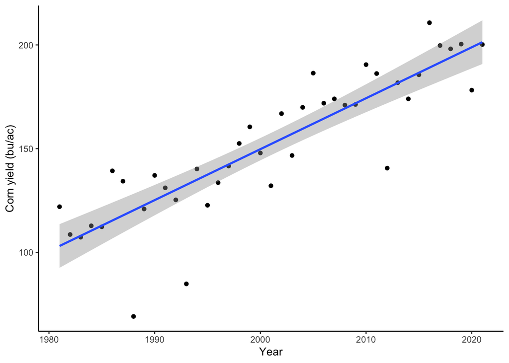

```r
#Plot relationship between year and yields
ggplot(winne_corn, aes(x = year, y = yield)) +
  geom_point() + theme_classic() +
  xlab("Year") + ylab("Corn yield (bu/ac)") +
  geom_smooth(method = "lm")
```

### Question 1b: Fit a quadratic time trend (i.e., year + year^2) and make a plot. Is there evidence for slowing yield growth?

There is no evidence for slowing yield growth in Winneshiek county over the study period. The addition of a $year^2$ term does not improve the model fit, and the coefficient estimate for $year^2$ is not significant. If there was evidence for a slowing yield trend, we would expect a significant, negative coefficient for the $year^2$ term.

```r
#add year^2 term to the model
winne_corn$year2 <- winne_corn$year^2
mod2 <- lm(yield~year + year2, winne_corn)
summary(mod2)
```

```
##
## Call:
## lm(formula = yield ~ year + year2, data = winne_corn)
##
## Residuals:
##     Min      1Q  Median      3Q     Max
## -51.384  -3.115   1.388   9.743  25.324
##
## Coefficients:
##               Estimate Std. Error t value Pr(>|t|)
## (Intercept)  2.583e+04  8.580e+04   0.301    0.765
## year        -2.812e+01  8.576e+01  -0.328    0.745
## year2        7.641e-03  2.143e-02   0.357    0.723
##
## Residual standard error: 17.17 on 38 degrees of freedom
## Multiple R-squared:  0.7559, Adjusted R-squared:  0.7431
## F-statistic: 58.84 on 2 and 38 DF,  p-value: 2.311e-12
```

```r
#compare linear and quadratic models; no improvement from adding the quadratic term
anova(mod1, mod2)
```

```
## Analysis of Variance Table
##
## Model 1: yield ~ year
## Model 2: yield ~ year + year2
##   Res.Df   RSS Df Sum of Sq      F Pr(>F)
## 1     39 11235
## 2     38 11198  1    37.466 0.1271 0.7234
```

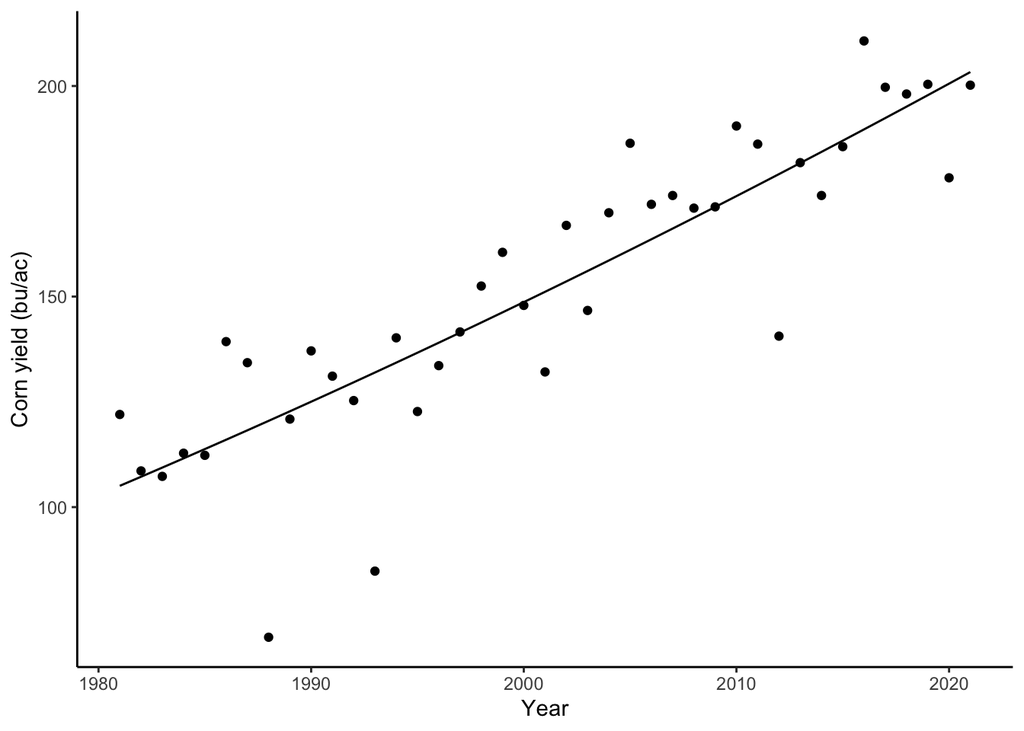

```r
#Plot relationship between year and yields and overlay the fitted quadratic regression line
ggplot(winne_corn, aes(x = year, y = yield)) +
  geom_point() + theme_classic() +
  xlab("Year") + ylab("Corn yield (bu/ac)") +
  geom_line(aes(y = mod2$fitted.values))
```

### Question 2 – Time Series: Let’s analyze the relationship between temperature and yields for the Winneshiek County time series. Use data on yield and summer avg Tmax. Is adding year or Tmax^2 to your model helpful? Make a plot and interpret the results.

There is no significant linear relationship between yields and tmax. Adding tmax to the regression of yields by year does not improve the model fit, and the coefficient estimate for tmax is not significant. However, there is a significant quadratic relationship between yields and tmax, indicating that yields increase with increasing temperatures up to a particular value of tmax, at which point yields decrease with further increases in tmax.

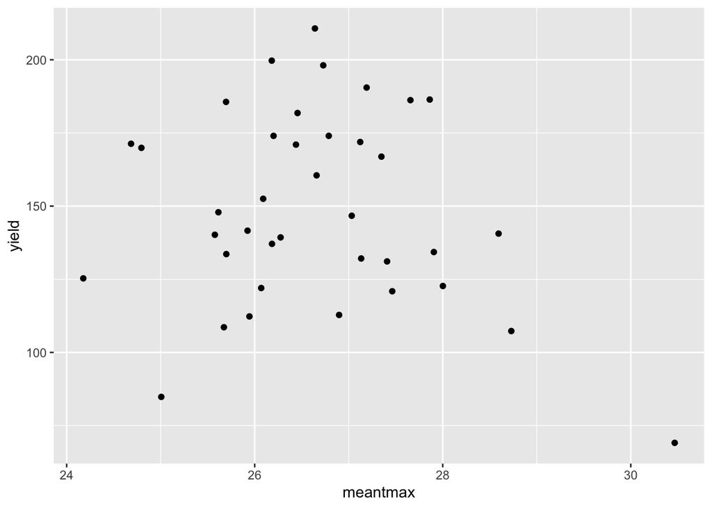

```r
#merge temperature and yield data
winne_yield_temp <- merge(winnesummer, winne_corn, by = "year")

#Plot relationship between yield and temperature
ggplot(winne_yield_temp, aes(x = meantmax, y = yield)) + geom_point()
```

```r
#fit a model of yield by mean tmax
mod3 <- lm(yield~meantmax, winne_yield_temp)
summary(mod3)
```

```
##
## Call:
## lm(formula = yield ~ meantmax, data = winne_yield_temp)
##
## Residuals:
##    Min     1Q Median     3Q    Max
## -71.96 -19.85  -3.19  24.64  61.72
##
## Coefficients:
##             Estimate Std. Error t value Pr(>|t|)
## (Intercept)  275.876    118.335   2.331   0.0255 *
## meantmax      -4.763      4.438  -1.073   0.2902
## ---
## Signif. codes:  0 '***' 0.001 '**' 0.01 '*' 0.05 '.' 0.1 ' ' 1
##
## Residual standard error: 32.88 on 36 degrees of freedom
## Multiple R-squared:  0.03101,    Adjusted R-squared:  0.004098
## F-statistic: 1.152 on 1 and 36 DF,  p-value: 0.2902
```

```r
#fit a model of yield including both year and tmax
mod4 <- lm(yield~meantmax + year, winne_yield_temp)
summary(mod4)
```

```
##
## Call:
## lm(formula = yield ~ meantmax + year, data = winne_yield_temp)
##
## Residuals:
##     Min      1Q  Median      3Q     Max
## -53.071  -7.269   2.271   9.935  27.505
##
## Coefficients:
##              Estimate Std. Error t value Pr(>|t|)
## (Intercept) -4791.774    513.812  -9.326 5.10e-11 ***
## meantmax       -3.201      2.308  -1.387    0.174
## year            2.514      0.253   9.934 1.01e-11 ***
## ---
## Signif. codes:  0 '***' 0.001 '**' 0.01 '*' 0.05 '.' 0.1 ' ' 1
##
## Residual standard error: 17.06 on 35 degrees of freedom
## Multiple R-squared:  0.7463, Adjusted R-squared:  0.7318
## F-statistic: 51.48 on 2 and 35 DF,  p-value: 3.761e-11
```

```r
#fit a model of yield including a quadratic term for tmax
winne_yield_temp$meantmax2 <- winne_yield_temp$meantmax^2
mod5 <- lm(yield~meantmax + meantmax2, winne_yield_temp)
summary(mod5)
```

```
##
## Call:
## lm(formula = yield ~ meantmax + meantmax2, data = winne_yield_temp)
##
## Residuals:
##     Min      1Q  Median      3Q     Max
## -56.587 -22.262  -0.982  22.409  52.798
##
## Coefficients:
##              Estimate Std. Error t value Pr(>|t|)
## (Intercept) -4223.604   1446.639  -2.920  0.00609 **
## meantmax      328.918    107.068   3.072  0.00410 **
## meantmax2      -6.173      1.979  -3.119  0.00362 **
## ---
## Signif. codes:  0 '***' 0.001 '**' 0.01 '*' 0.05 '.' 0.1 ' ' 1
##
## Residual standard error: 29.5 on 35 degrees of freedom
## Multiple R-squared:  0.2417, Adjusted R-squared:  0.1984
## F-statistic: 5.579 on 2 and 35 DF,  p-value: 0.007887
```

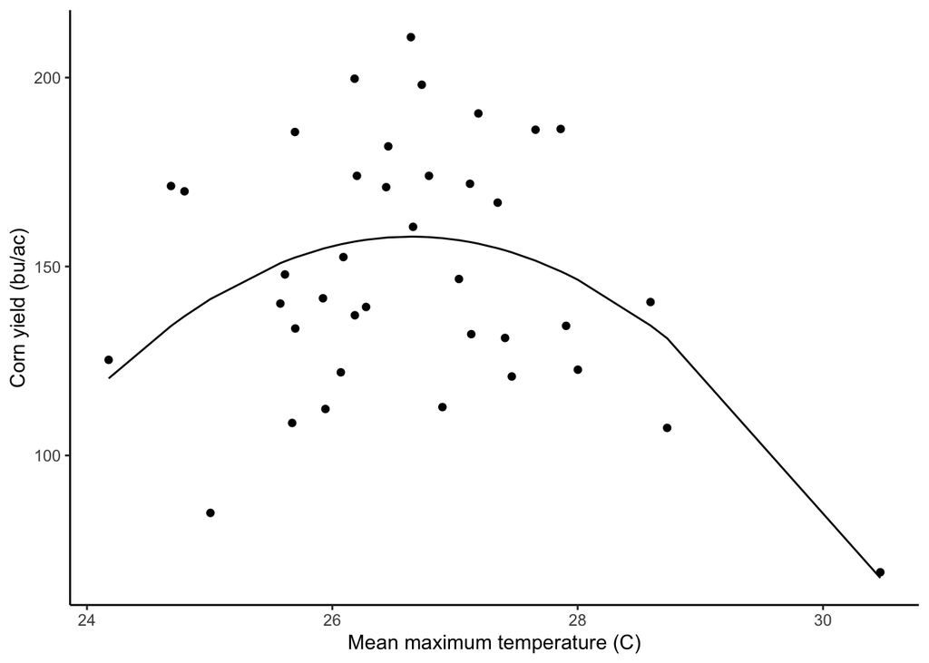

```r
#Plot fitted quadratic relationship between yield and temperature from mod5 (yield~tmax + tmax2)
ggplot(winne_yield_temp, aes(x = meantmax, y = yield)) +
  geom_point() + theme_classic() +
  geom_line(aes(y = mod5$fitted.values)) +
  xlab("Mean maximum temperature (C)") +
  ylab("Corn yield (bu/ac)")
```

### Question 3 – Cross-Section: Analyze the relationship between temperature and yield across all counties in 2018. Is there a relationship? Interpret the results.

Plotting county-level Iowa corn yields in 2018 by mean maximum summertime temperature suggests that there may be a quadratic relationship between corn yield and temperature, with maximum yields generally appearing around temperatures of ~28 degrees C. Regression results support this interpretation. The linear relationship between tmax and yield is only marginally significant ($p = 0.063$) and weak ($R^2 = 0.027$), but both terms in the quadratic regression are significant ($p < 0.01$ for both), and the explanatory power of the model improves ($R^2 = 0.11$).

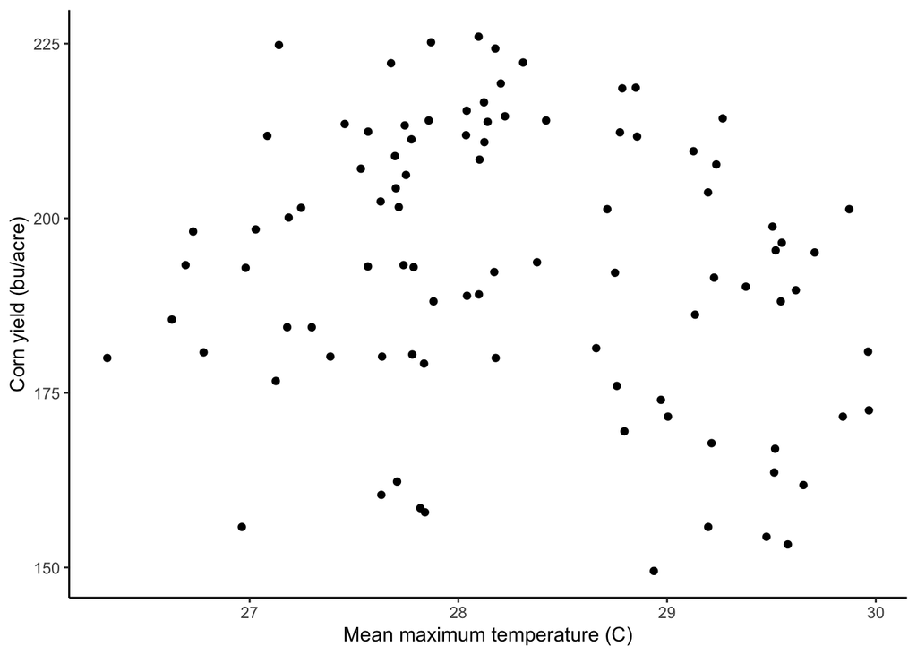

```r
#Subset yields from 2018
corn_2018 <- subset(cornyields, year == 2018)

#Subset and summarize summer temperatures in 2018 for all IA counties
tmax_2018 <- tmaxdf %>%
  filter(year == 2018 & doy >= 152 & doy <= 243) %>%
  group_by(countyfp) %>%
  summarize(meantmax = mean(tmax))

#Merge temperature and yield data based on county codes
corn_2018 <- merge(corn_2018, tmax_2018, by.x = "county_ansi", by.y = "countyfp")

#Visualize the relationship between yield and temperature
ggplot(corn_2018, aes(x = meantmax, y = yield)) +
  geom_point() + theme_classic() +
  ylab("Corn yield (bu/acre)") + xlab("Mean maximum temperature (C)")
```

```r
#Regress yields by temperature
mod6 <- lm(yield ~ meantmax, corn_2018)
summary(mod6)
```

```
##
## Call:
## lm(formula = yield ~ meantmax, data = corn_2018)
##
## Residuals:
##     Min      1Q  Median      3Q     Max
## -42.983 -15.041   0.955  16.795  31.999
##
## Coefficients:
##             Estimate Std. Error t value Pr(>|t|)
## (Intercept)  312.466     63.387   4.929 3.69e-06 ***
## meantmax      -4.216      2.241  -1.882   0.0631 .
## ---
## Signif. codes:  0 '***' 0.001 '**' 0.01 '*' 0.05 '.' 0.1 ' ' 1
##
## Residual standard error: 19.64 on 91 degrees of freedom
## Multiple R-squared:  0.03745,    Adjusted R-squared:  0.02687
## F-statistic: 3.541 on 1 and 91 DF,  p-value: 0.06308
```

```r
#Try adding a quadratic temperature term
corn_2018$tmax2 <- corn_2018$meantmax^2
mod7 <- lm(yield ~ meantmax + tmax2, corn_2018)
summary(mod7)
```

```
##
## Call:
## lm(formula = yield ~ meantmax + tmax2, data = corn_2018)
##
## Residuals:
##     Min      1Q  Median      3Q     Max
## -44.221 -15.399   5.007  14.541  30.879
##
## Coefficients:
##              Estimate Std. Error t value Pr(>|t|)
## (Intercept) -5501.602   1860.830  -2.957  0.00397 **
## meantmax      406.789    131.493   3.094  0.00263 **
## tmax2          -7.256      2.321  -3.126  0.00239 **
## ---
## Signif. codes:  0 '***' 0.001 '**' 0.01 '*' 0.05 '.' 0.1 ' ' 1
##
## Residual standard error: 18.75 on 90 degrees of freedom
## Multiple R-squared:  0.1317, Adjusted R-squared:  0.1124
## F-statistic: 6.827 on 2 and 90 DF,  p-value: 0.001736
```

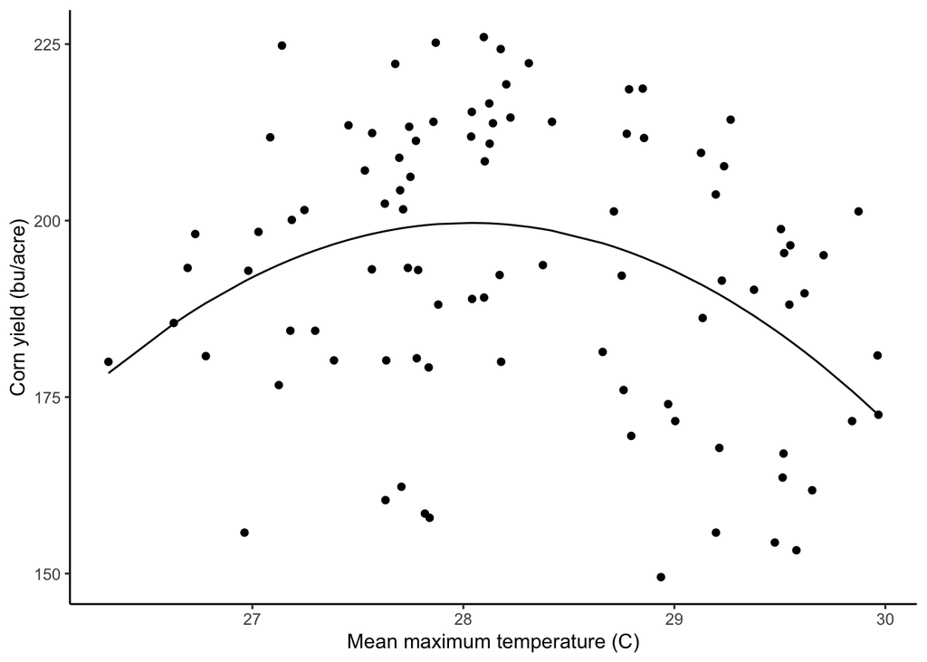

```r
#Replot data including the quadratic trend
ggplot(corn_2018, aes(x = meantmax, y = yield)) +
  geom_point() + theme_classic() +
  ylab("Corn yield (bu/acre)") + xlab("Mean maximum temperature (C)") +
  geom_line(aes(y = mod7$fitted.values))
```

### Question 4 – Panel: One way to leverage multiple time series is to group all data into what is called a “panel” regression. Convert the county ID code (“countyfp” or “county_ansi”) into factor using as.factor, then include this variable in a regression using all counties’ yield and summer temperature data. How does the significance of your temperature coefficients (Tmax, Tmax^2) change? Make a plot comparing actual and fitted yields and interpret the results of your model.

The model of yield including summer tmax, summer $tmax^2$, and a factor for county is significant, and the addition of the county term improves the explanatory power of the model relative to the model without the county term ($Adj. R^2$ increases from 0.19 to 0.24). The coefficient estimates for tmax (167.97) and $tmax^2$ (-3.13) are significant at $p < 0.0001$, and indicate that there is a positive relationship between yield and temperature up to a particular value of temperature, beyond which the relationship between yield and temperature is negative. These coefficient estimates are not significantly different than the coefficient estimates from the model excluding the county term (168.96 for tmax and -3.17 for $tmax^2$). However, the plot of modeled vs. observed yields suggests that there may be some heteroskedasticity in the residuals. Adding year to the model substantially improves model fit ($R^2$ increases to 0.71) and improves the distribution of the residuals.

```r
#Calculate summer temperature for all years and counties and calculate tmax^2
tmax_summer <- tmaxdf %>%
  filter(doy >= 152 & doy <= 243) %>%
  group_by(countyfp, year) %>%
  summarize(meantmax = mean(tmax), tmax2 = (mean(tmax))^2) %>%
  rename(county_ansi = countyfp)
#Merge temps with corn yield data,  convert county to a factor
corn_and_temp <- merge(cornyields, tmax_summer, by = c("county_ansi", "year"))
corn_and_temp$county_ansi <- as.factor(as.character(corn_and_temp$county_ansi))

#Fit quadratic model of yields by temperature without county
mod8 <- lm(yield ~ meantmax + tmax2, corn_and_temp)
summary(mod8)
```

```
##
## Call:
## lm(formula = yield ~ meantmax + tmax2, data = corn_and_temp)
##
## Residuals:
##      Min       1Q   Median       3Q      Max
## -113.151  -21.982   -2.794   24.860   82.006
##
## Coefficients:
##               Estimate Std. Error t value Pr(>|t|)
## (Intercept) -2098.6219   139.4315  -15.05   <2e-16 ***
## meantmax      168.9590     9.9402   17.00   <2e-16 ***
## tmax2          -3.1665     0.1769  -17.90   <2e-16 ***
## ---
## Signif. codes:  0 '***' 0.001 '**' 0.01 '*' 0.05 '.' 0.1 ' ' 1
##
## Residual standard error: 31.55 on 3745 degrees of freedom
## Multiple R-squared:  0.1947, Adjusted R-squared:  0.1943
## F-statistic: 452.8 on 2 and 3745 DF,  p-value: < 2.2e-16
```

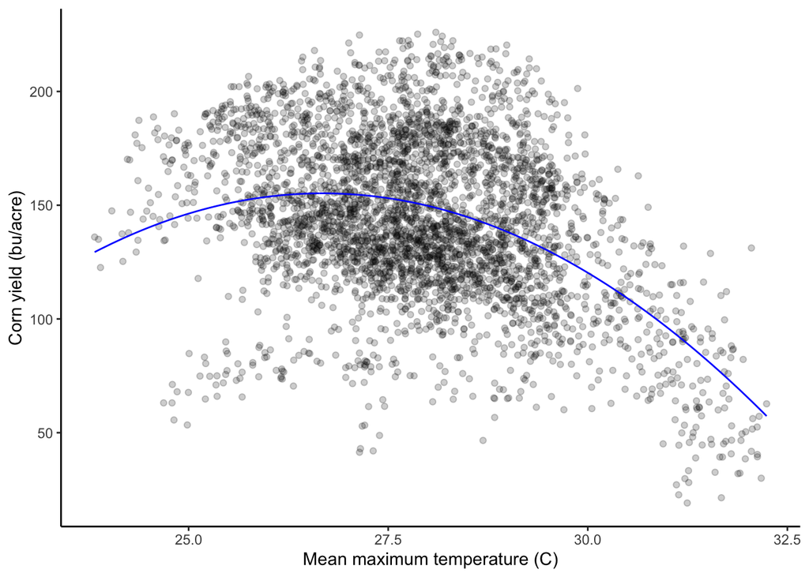

```r
#Plot relationship between yields and temperature with the fitted regression line
ggplot(corn_and_temp, aes(x = meantmax, y = yield)) +
  geom_point(alpha = 0.2) + theme_classic() +
  ylab("Corn yield (bu/acre)") + xlab("Mean maximum temperature (C)") +
  geom_line(color = "blue", aes(y = mod8$fitted.values))
```

```r
#Refit quadratic model of yields by temperature including county as a fixed effect
mod9 <- lm(yield ~ meantmax + tmax2 + county_ansi, corn_and_temp)
summary(mod9)
```

```
##
## Call:
## lm(formula = yield ~ meantmax + tmax2 + county_ansi, data = corn_and_temp)
##
## Residuals:
##     Min      1Q  Median      3Q     Max
## -95.088 -21.438  -3.026  23.570  77.941
##
## Coefficients:
##                  Estimate Std. Error t value Pr(>|t|)
## (Intercept)    -2102.2327   139.2946 -15.092  < 2e-16 ***
## meantmax         167.9699     9.8950  16.975  < 2e-16 ***
## tmax2             -3.1324     0.1758 -17.820  < 2e-16 ***
## county_ansi101     2.1063     7.0445   0.299 0.764958
## county_ansi103     3.8916     7.0404   0.553 0.580470
## county_ansi105     6.8541     7.0503   0.972 0.331025
## county_ansi107     2.4290     7.0390   0.345 0.730052
## county_ansi109    11.2195     7.0616   1.589 0.112188
## county_ansi11      6.2752     7.0459   0.891 0.373195
## county_ansi111     3.2019     7.0439   0.455 0.649452
## county_ansi113     5.5167     7.0475   0.783 0.433799
## county_ansi115     8.0182     7.0400   1.139 0.254798
## county_ansi117   -23.7701     7.1360  -3.331 0.000874 ***
## county_ansi119     8.4973     7.0446   1.206 0.227815
## county_ansi121    -2.7616     7.0390  -0.392 0.694843
## county_ansi123     8.2674     7.0389   1.175 0.240260
## county_ansi125     2.0919     7.0389   0.297 0.766339
## county_ansi127    13.1465     7.0469   1.866 0.062181 .
## county_ansi129     9.7388     7.1425   1.364 0.172806
## county_ansi13      6.2028     7.0520   0.880 0.379147
## county_ansi131     6.9486     7.0897   0.980 0.327099
## county_ansi133     1.2117     7.0395   0.172 0.863346
## county_ansi135   -16.6425     7.0863  -2.349 0.018900 *
## county_ansi137     6.6056     7.0404   0.938 0.348183
## county_ansi139     8.2715     7.0389   1.175 0.240027
## county_ansi141    13.1679     7.0506   1.868 0.061894 .
## county_ansi143     7.9469     7.0654   1.125 0.260765
## county_ansi145     0.4131     7.0406   0.059 0.953217
## county_ansi147     6.1297     7.0527   0.869 0.384835
## county_ansi149     6.7353     7.0404   0.957 0.338798
```

[output cut: 62 more lines]

```
## county_ansi85      7.0324     7.0390   0.999 0.317828
## county_ansi87      5.8050     7.0396   0.825 0.409641
## county_ansi89      0.9492     7.1084   0.134 0.893781
## county_ansi9       4.3024     7.0416   0.611 0.541240
## county_ansi91      8.8848     7.0596   1.259 0.208279
## county_ansi93     10.8610     7.0456   1.542 0.123276
## county_ansi95      6.7101     7.0403   0.953 0.340600
## county_ansi97     -2.2777     7.0533  -0.323 0.746768
## county_ansi99     13.8935     7.0402   1.973 0.048519 *
## ---
## Signif. codes:  0 '***' 0.001 '**' 0.01 '*' 0.05 '.' 0.1 ' ' 1
##
## Residual standard error: 30.68 on 3647 degrees of freedom
## Multiple R-squared:  0.2585, Adjusted R-squared:  0.2382
## F-statistic: 12.71 on 100 and 3647 DF,  p-value: < 2.2e-16
```

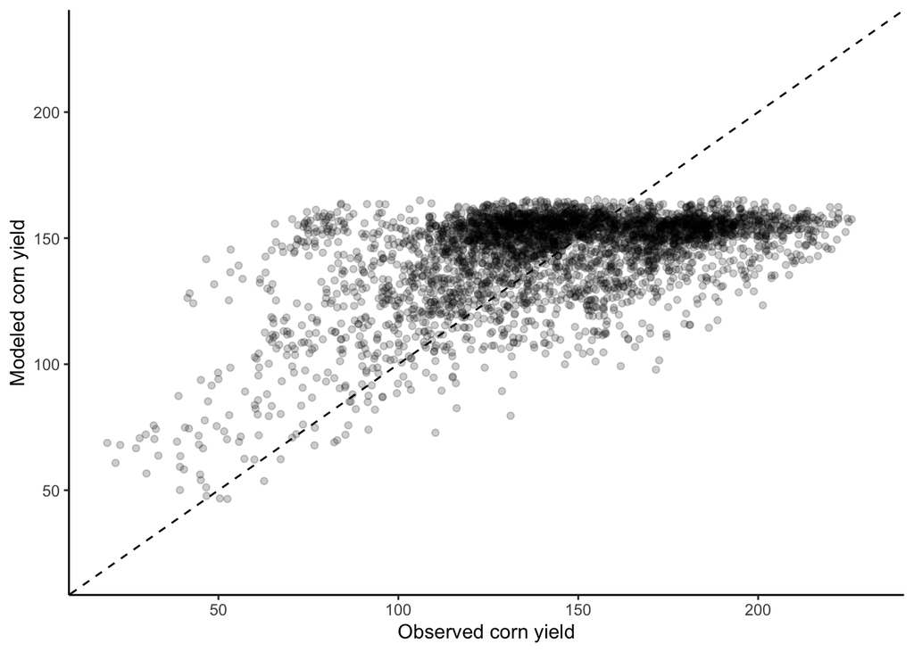

```r
#Store fitted values from the panel regression and plot observed vs. fitted values
corn_and_temp$fitted <- mod9$fitted.values
ggplot(corn_and_temp, aes(x = yield, y = fitted)) +
  geom_point(alpha = 0.2) + theme_classic() +
  ylab("Modeled corn yield") + xlab("Observed corn yield") +
  xlim(19, 230) + ylim(19, 230) + #set axis limits to better see how close to 1:1 the relationship is
  geom_abline(intercept = 0, slope = 1, linetype = "dashed") #add dashed identity line
```

```r
#Try adding  year term to improve fit and heteroskedasticity:
mod9 <- lm(yield ~ meantmax + tmax2 + year + county_ansi, corn_and_temp)
summary(mod9)
```

```
##
## Call:
## lm(formula = yield ~ meantmax + tmax2 + year + county_ansi, data = corn_and_temp)
##
## Residuals:
##     Min      1Q  Median      3Q     Max
## -81.645  -9.720   1.924  13.232  40.409
##
## Coefficients:
##                  Estimate Std. Error t value Pr(>|t|)
## (Intercept)    -5.826e+03  9.804e+01 -59.431  < 2e-16 ***
## meantmax        1.182e+02  6.108e+00  19.352  < 2e-16 ***
## tmax2          -2.225e+00  1.085e-01 -20.503  < 2e-16 ***
## year            2.203e+00  2.836e-02  77.664  < 2e-16 ***
## county_ansi101  5.352e-01  4.325e+00   0.124 0.901510
## county_ansi103  4.380e+00  4.322e+00   1.013 0.310971
## county_ansi105  7.730e+00  4.328e+00   1.786 0.074158 .
## county_ansi107  2.203e+00  4.321e+00   0.510 0.610224
## county_ansi109  1.222e+01  4.335e+00   2.819 0.004839 **
## county_ansi11   7.186e+00  4.325e+00   1.661 0.096732 .
## county_ansi111  1.779e+00  4.324e+00   0.411 0.680740
## county_ansi113  6.415e+00  4.326e+00   1.483 0.138218
## county_ansi115  7.330e+00  4.322e+00   1.696 0.089966 .
## county_ansi117 -2.168e+01  4.381e+00  -4.949 7.81e-07 ***
## county_ansi119  9.328e+00  4.325e+00   2.157 0.031063 *
## county_ansi121 -2.587e+00  4.321e+00  -0.599 0.549390
## county_ansi123  8.152e+00  4.321e+00   1.887 0.059302 .
## county_ansi125  1.919e+00  4.321e+00   0.444 0.656948
## county_ansi127  1.418e+01  4.326e+00   3.278 0.001055 **
## county_ansi129  1.023e+01  4.385e+00   2.332 0.019741 *
## county_ansi13   7.289e+00  4.329e+00   1.684 0.092303 .
## county_ansi131  7.285e+00  4.352e+00   1.674 0.094242 .
## county_ansi133  7.987e-01  4.321e+00   0.185 0.853378
## county_ansi135 -1.585e+01  4.350e+00  -3.643 0.000273 ***
## county_ansi137  5.885e+00  4.322e+00   1.362 0.173381
## county_ansi139  8.283e+00  4.321e+00   1.917 0.055337 .
## county_ansi141  1.423e+01  4.328e+00   3.288 0.001018 **
## county_ansi143  8.743e+00  4.337e+00   2.016 0.043890 *
## county_ansi145 -3.674e-01  4.322e+00  -0.085 0.932261
## county_ansi147  7.261e+00  4.330e+00   1.677 0.093601 .
```

[output cut: 63 more lines]

```
## county_ansi85   6.891e+00  4.321e+00   1.595 0.110834
## county_ansi87   5.280e+00  4.321e+00   1.222 0.221864
## county_ansi89   9.433e-01  4.364e+00   0.216 0.828875
## county_ansi9    5.068e+00  4.323e+00   1.172 0.241144
## county_ansi91   9.881e+00  4.334e+00   2.280 0.022661 *
## county_ansi93   1.186e+01  4.325e+00   2.743 0.006124 **
## county_ansi95   7.214e+00  4.322e+00   1.669 0.095161 .
## county_ansi97  -1.386e+00  4.330e+00  -0.320 0.748823
## county_ansi99   1.440e+01  4.322e+00   3.332 0.000871 ***
## ---
## Signif. codes:  0 '***' 0.001 '**' 0.01 '*' 0.05 '.' 0.1 ' ' 1
##
## Residual standard error: 18.83 on 3646 degrees of freedom
## Multiple R-squared:  0.7207, Adjusted R-squared:  0.7129
## F-statistic: 93.13 on 101 and 3646 DF,  p-value: < 2.2e-16
```

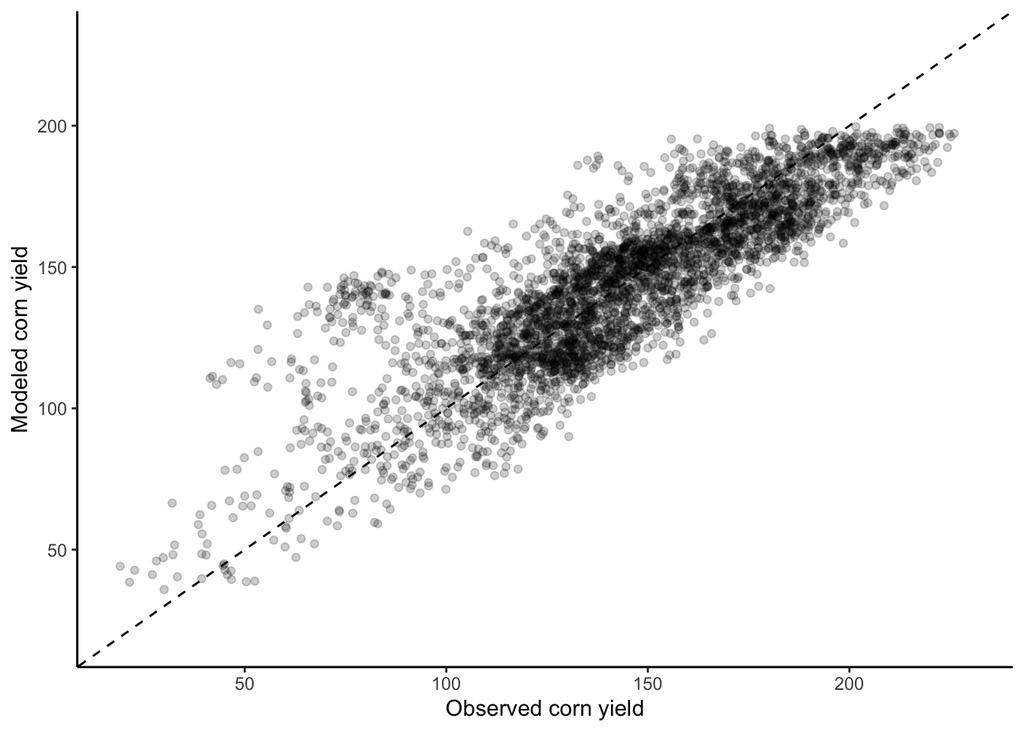

```r
corn_and_temp$fitted <- mod9$fitted.values
ggplot(corn_and_temp, aes(x = yield, y = fitted)) +
  geom_point(alpha = 0.2) + theme_classic() +
  ylab("Modeled corn yield") + xlab("Observed corn yield") +
  xlim(19, 230) + ylim(19, 230) +
  geom_abline(intercept = 0, slope = 1, linetype = "dashed")
```

### Question 5 – Soybeans: Download NASS data on soybean yields and explore either a time series relationship for a given county, the cross-sectional relationship for a given year, or a panel across all counties and years.

I explored the cross-sectional relationship between soybean yields and summer temperatures in 2018. There is a significant quadratic relationship between soybean yields and mean summer temperatures across Iowa counties in 2018. Soybean yields respond to temperature similarly to corn, with increases in yields up to ~28 degrees C, beyond which yields begin to decline.

```r
#Define and pull data
params <- list(commodity_desc = "SOYBEANS", prodn_practice_desc = "ALL PRODUCTION PRACTICES", year__GE = 1981, state_alpha = "IA", reference_period_desc = "YEAR", agg_level_desc = "COUNTY")
soyyield_all <- nassqs_yields(params)
```

```r
#Clean up dataframe and drop NAs
soyyield <- soyyield_all %>%
  select(county_ansi, county_name, Value, year) %>%
  mutate(county_ansi = as.numeric(county_ansi), yield = as.numeric(Value)) %>%
  filter(!is.na(county_ansi) & !is.na(Value))

##Look at the cross-sectional relationship between soybean yields and tmax for 2018
#subset soybean yields and merge with tmax, add a column for tmax^2
soy_2018 <- subset(soyyield, year == 2018)
soy_2018 <- merge(soy_2018, tmax_2018, by.x = "county_ansi", by.y = "countyfp")
soy_2018$tmax2 <- soy_2018$meantmax^2

#Try fitting a quadratic model of soy yields; both terms are significant
mod10 <- lm(yield ~ meantmax + tmax2, soy_2018)
summary(mod10)
```

```
##
## Call:
## lm(formula = yield ~ meantmax + tmax2, data = soy_2018)
##
## Residuals:
##      Min       1Q   Median       3Q      Max
## -12.0464  -3.7212   0.3655   3.5239  12.6002
##
## Coefficients:
##               Estimate Std. Error t value Pr(>|t|)
## (Intercept) -1401.3584   453.0686  -3.093  0.00262 **
## meantmax      103.5349    31.9520   3.240  0.00166 **
## tmax2          -1.8371     0.5629  -3.264  0.00154 **
## ---
## Signif. codes:  0 '***' 0.001 '**' 0.01 '*' 0.05 '.' 0.1 ' ' 1
##
## Residual standard error: 4.9 on 93 degrees of freedom
## Multiple R-squared:  0.1192, Adjusted R-squared:  0.1002
## F-statistic:  6.29 on 2 and 93 DF,  p-value: 0.00274
```

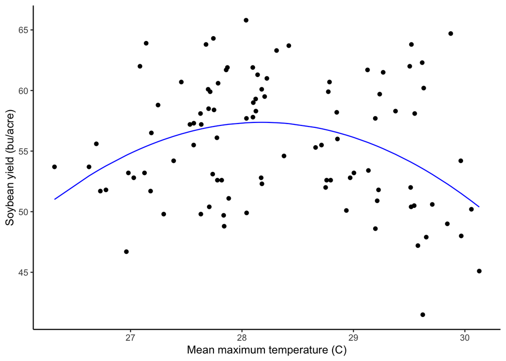

```r
#Plot soy yield by tmax
ggplot(soy_2018, aes(x = meantmax, y = yield)) +
  geom_point() + theme_classic() +
  ylab("Soybean yield (bu/acre)") + xlab("Mean maximum temperature (C)") +
  geom_line(color = "blue", aes(y = mod10$fitted.values))
```

### Bonus: Find a package to make a county map of Iowa displaying some sort of information about yields or weather. Interpret your map.

This map shows county-level yields of soybeans in Iowa in 2018. Darker colors correspond to higher yields; yields tend to be highest in the southeast and northwest corners of the state, and lowest in the south central portion of the state.

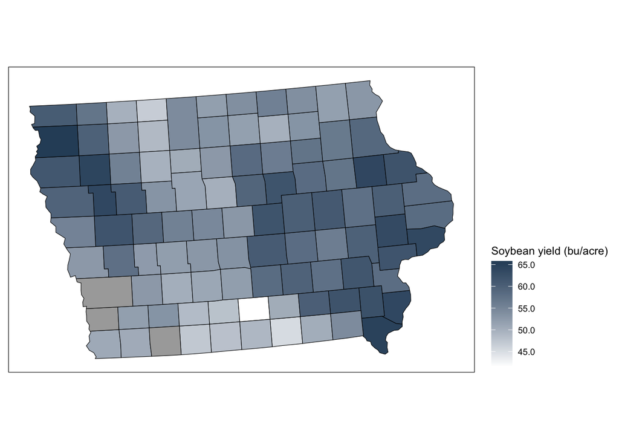

```r
library(usmap)

#The usmap function takes a 2-column data frame containing the fips code and the value of interest. So, we need to combine the state fips codes with the county ansi codes that contain leading zeros.
soyyield <- soyyield_all %>%
  filter(!county_ansi == "") %>% #removes any blanks in the county ansi code column
  mutate(county_ansi = paste0(state_ansi, county_ansi), yield = as.numeric(Value)) %>%
  filter(year == 2018 & !is.na(Value)) %>%
  select(county_ansi, county_name, yield, year)

#Plot 2018 soybean yields in Iowa
plotdf <- soyyield[,c("county_ansi", "yield")]
colnames(plotdf) <- c("fips", "yield")
plot_usmap(regions = "counties", data = plotdf, values = "yield", include = c("IA"), size = 0.2) + #define data and area to be plotted and boundary weights
  scale_fill_continuous(na.value= "darkgrey", low = "white", high = "#2d4d68",
                        name = "Soybean yield (bu/acre)", label = scales::comma) + #adjust color scale
  theme(legend.position = "right") + #adjust legend position
  theme(panel.background = element_rect(colour = "black")) #adjust aesthetics
```

### Bonus #2: Challenge question - map trends in corn yields by county across Iowa. Interpret your map.

All counties in Iowa have experienced a significant increase in soybean yields over this 41-year period. Annual rates of increase ranged from 0.41 bushels per acre per year to 0.69 bushels per acre per year, with a mean rate of increase of 0.53 bushels per acre per year. The map of county-level estimates for the rate of increase suggests that the largest increases have occurred in the northern and western parts of the state, while smaller increases occured in the central part of the state.

```r
##Here, we want to fit a linear model of yield ~ year to each county and store the year coefficients for each county in a dataframe. Then, we can map the coefficients to see if yield increased faster in some counties than others.

#Preprocess the data to remove NAs, combine state and county fips codes, select desired columns, and group by county
soyyield_grouped <- soyyield_all %>%
  filter(!county_ansi == "") %>% #removes any blanks in the county ansi code column
  mutate(county_ansi = paste0(state_ansi, county_ansi), yield = as.numeric(Value)) %>% #combines state and county ansi, converts yield to numeric
  filter(!is.na(yield)) %>%
  select(county_ansi, county_name, yield, year) %>%
  group_by(county_ansi) #Groups the data by county

##Fit the lm to each county and store the output
library(broom) #The broom package makes it easy to store lm outputs
#"do" iterates the function over a grouped data frame. "tidy" stores model coefficients as a data frame.
lm_out <- do(soyyield_grouped, tidy(lm(yield ~ year, data = .))) %>%
  filter(term == "year") #we only care about the slope coefficients, not the intercepts

#Check to see if any regressions of yield~year are insignificant
unique(lm_out$p.value > 0.05) #all significant
```

```
## [1] FALSE
```

```r
summary(lm_out$estimate)
```

```
##    Min. 1st Qu.  Median    Mean 3rd Qu.    Max.
##  0.4115  0.4957  0.5295  0.5331  0.5717  0.6893
```

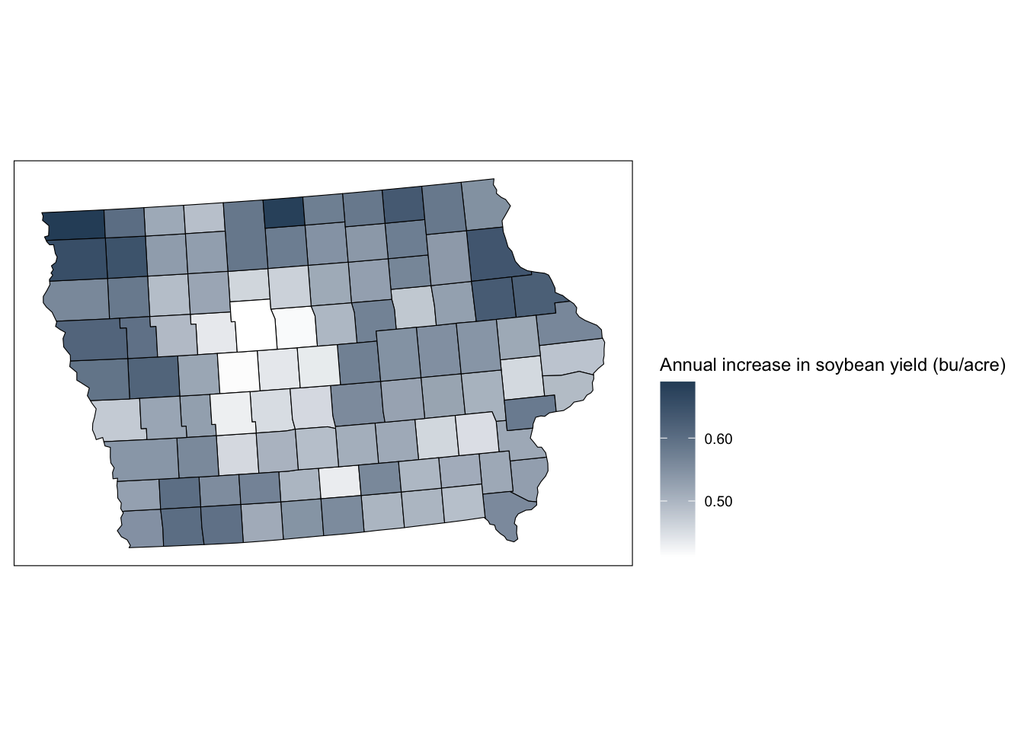

```r
##Map the model coefficients
plotdf <- lm_out[,c("county_ansi", "estimate")]
colnames(plotdf) <- c("fips", "estimate")
plot_usmap(regions = "counties", data = plotdf, values = "estimate", include = c("IA"), size = 0.2) +
  scale_fill_continuous(na.value= "darkgrey", low = "white", high = "#2d4d68",
                        name = "Annual increase in soybean yield (bu/acre)", label = scales::comma) +
  theme(legend.position = "right") +
  theme(panel.background = element_rect(colour = "black"))
```